# Ecommerce

Melisa

19 July 2020

# Business understanding

Kira Plastinina is a Russian brand that is sold through a defunct chain of retail stores in Russia, Ukraine, Kazakhstan, Belarus, China, Philippines, and Armenia. Kira Plastinina, the world’s youngest fashion designer who opened her first boutique when she was just 14, is one of the most disputed fashion figures in Russia. Fans of her clothing argue that she’s brought a breath of fresh air to the industry

# Business objectives

The brand’s Sales and Marketing team would like to understand their customer’s behavior from data that they have collected over the past year. More specifically, they would like to learn the characteristics of customer groups.

# Assessing the situation at hand

## Resources inventory

### Datasets

Dataset url<-<- http://bit.ly/EcommerceCustomersDataset

Software (Github,R)

# Assumptions

The data is up to date and relevant.

# Dataset information

- The dataset consists of 10 numerical and 8 categorical attributes. The ‘Revenue’ attribute can be used as the class label.
- “Administrative”, “Administrative Duration”, “Informational”, “Informational Duration”, “Product Related” and “Product Related Duration” represents the number of different types of pages visited by the visitor in that session and total time spent in each of these page categories. The values of these features are derived from the URL information of the pages visited by the user and updated in real-time when a user takes an action, e.g. moving from one page to another.
- The “Bounce Rate”, “Exit Rate” and “Page Value” features represent the metrics measured by “Google Analytics” for each page in the e-commerce site.
- The value of the “Bounce Rate” feature for a web page refers to the percentage of visitors who enter the site from that page and then leave (“bounce”) without triggering any other requests to the analytics server during that session.
- The value of the “Exit Rate” feature for a specific web page is calculated as for all pageviews to the page, the percentage that was the last in the session.
- The “Page Value” feature represents the average value for a web page that a user visited before completing an e-commerce transaction.
- The “Special Day” feature indicates the closeness of the site visiting time to a specific special day (e.g. Mother’s Day, Valentine’s Day) in which the sessions are more likely to be finalized with the transaction. The value of this attribute is determined by considering the dynamics of e-commerce such as the duration between the order date and delivery date. For example, for Valentina’s day, this value takes a nonzero value between February 2 and February 12, zero before and after this date unless it is close to another special day, and its maximum value of 1 on February 8.
- The dataset also includes the operating system, browser, region, traffic type, visitor type as returning or new visitor, a Boolean value indicating whether the date of the visit is weekend, and month of the year.

# Constraints

There are no constraints currently

# Load necessary libraries

```r
library(tidyverse)# Enables us to carry out data cleaning
library(DataExplorer)# Enables us to carry our EDA
```

```r
library(ggcorrplot)# Enables us to plot a correlation matrix
library(corrplot)
library(skimr)# Enables us to draw more information on our dataset
```

# Load in dataset

```r
ecommerce <-read_csv("online_shoppers_intention.csv")
view(ecommerce)
```

# Preview of head of our dataset

```r
head(ecommerce)
```

| Administrative | Administrative_Duration | Informational | Informational_Duration | ProductRelated | ProductRelated_Duration | BounceRates | ExitRates | PageValues | SpecialDay | Month | OperatingSystems | Browser | Region | TrafficType | VisitorType | Weekend | Revenue |
| --- | --- | --- | --- | --- | --- | --- | --- | --- | --- | --- | --- | --- | --- | --- | --- | --- | --- |
| 0 | 0 | 0 | 0 | 1 | 0.000000 | 0.20000000 | 0.2000000 | 0 | 0 | Feb | 1 | 1 | 1 | 1 | Returning_Visitor | FALSE | FALSE |
| 0 | 0 | 0 | 0 | 2 | 64.000000 | 0.00000000 | 0.1000000 | 0 | 0 | Feb | 2 | 2 | 1 | 2 | Returning_Visitor | FALSE | FALSE |
| 0 | -1 | 0 | -1 | 1 | -1.000000 | 0.20000000 | 0.2000000 | 0 | 0 | Feb | 4 | 1 | 9 | 3 | Returning_Visitor | FALSE | FALSE |
| 0 | 0 | 0 | 0 | 2 | 2.666667 | 0.05000000 | 0.1400000 | 0 | 0 | Feb | 3 | 2 | 2 | 4 | Returning_Visitor | FALSE | FALSE |
| 0 | 0 | 0 | 0 | 10 | 627.500000 | 0.02000000 | 0.0500000 | 0 | 0 | Feb | 3 | 3 | 1 | 4 | Returning_Visitor | TRUE | FALSE |
| 0 | 0 | 0 | 0 | 19 | 154.216667 | 0.01578947 | 0.0245614 | 0 | 0 | Feb | 2 | 2 | 1 | 3 | Returning_Visitor | FALSE | FALSE |

# Preview of the tail of our dataset

```r
tail(ecommerce)
```

| Administrative | Administrative_Duration | Informational | Informational_Duration | ProductRelated | ProductRelated_Duration | BounceRates | ExitRates | PageValues | SpecialDay | Month | OperatingSystems | Browser | Region | TrafficType | VisitorType | Weekend | Revenue |
| --- | --- | --- | --- | --- | --- | --- | --- | --- | --- | --- | --- | --- | --- | --- | --- | --- | --- |
| 0 | 0 | 1 | 0 | 16 | 503.000 | 0.000000000 | 0.03764706 | 0.00000 | 0 | Nov | 2 | 2 | 1 | 1 | Returning_Visitor | FALSE | FALSE |
| 3 | 145 | 0 | 0 | 53 | 1783.792 | 0.007142857 | 0.02903061 | 12.24172 | 0 | Dec | 4 | 6 | 1 | 1 | Returning_Visitor | TRUE | FALSE |
| 0 | 0 | 0 | 0 | 5 | 465.750 | 0.000000000 | 0.02133333 | 0.00000 | 0 | Nov | 3 | 2 | 1 | 8 | Returning_Visitor | TRUE | FALSE |
| 0 | 0 | 0 | 0 | 6 | 184.250 | 0.083333333 | 0.08666667 | 0.00000 | 0 | Nov | 3 | 2 | 1 | 13 | Returning_Visitor | TRUE | FALSE |
| 4 | 75 | 0 | 0 | 15 | 346.000 | 0.000000000 | 0.02105263 | 0.00000 | 0 | Nov | 2 | 2 | 3 | 11 | Returning_Visitor | FALSE | FALSE |
| 0 | 0 | 0 | 0 | 3 | 21.250 | 0.000000000 | 0.06666667 | 0.00000 | 0 | Nov | 3 | 2 | 1 | 2 | New_Visitor | TRUE | FALSE |

# Summary of our dataset’s information

```r
names(ecommerce)
```

```
##  [1] "Administrative"          "Administrative_Duration"
##  [3] "Informational"           "Informational_Duration"
##  [5] "ProductRelated"          "ProductRelated_Duration"
##  [7] "BounceRates"             "ExitRates"
##  [9] "PageValues"              "SpecialDay"
## [11] "Month"                   "OperatingSystems"
## [13] "Browser"                 "Region"
## [15] "TrafficType"             "VisitorType"
## [17] "Weekend"                 "Revenue"
```

# Summary of our dataset

```r
summary(ecommerce)
```

```
##  Administrative   Administrative_Duration Informational
##  Min.   : 0.000   Min.   :  -1.00         Min.   : 0.000
##  1st Qu.: 0.000   1st Qu.:   0.00         1st Qu.: 0.000
##  Median : 1.000   Median :   8.00         Median : 0.000
##  Mean   : 2.318   Mean   :  80.91         Mean   : 0.504
##  3rd Qu.: 4.000   3rd Qu.:  93.50         3rd Qu.: 0.000
##  Max.   :27.000   Max.   :3398.75         Max.   :24.000
##  NA's   :14       NA's   :14              NA's   :14
##  Informational_Duration ProductRelated   ProductRelated_Duration
##  Min.   :  -1.00        Min.   :  0.00   Min.   :   -1.0
##  1st Qu.:   0.00        1st Qu.:  7.00   1st Qu.:  185.0
##  Median :   0.00        Median : 18.00   Median :  599.8
##  Mean   :  34.51        Mean   : 31.76   Mean   : 1196.0
##  3rd Qu.:   0.00        3rd Qu.: 38.00   3rd Qu.: 1466.5
##  Max.   :2549.38        Max.   :705.00   Max.   :63973.5
##  NA's   :14             NA's   :14       NA's   :14
##   BounceRates         ExitRates         PageValues        SpecialDay
##  Min.   :0.000000   Min.   :0.00000   Min.   :  0.000   Min.   :0.00000
##  1st Qu.:0.000000   1st Qu.:0.01429   1st Qu.:  0.000   1st Qu.:0.00000
##  Median :0.003119   Median :0.02512   Median :  0.000   Median :0.00000
##  Mean   :0.022152   Mean   :0.04300   Mean   :  5.889   Mean   :0.06143
##  3rd Qu.:0.016684   3rd Qu.:0.05000   3rd Qu.:  0.000   3rd Qu.:0.00000
##  Max.   :0.200000   Max.   :0.20000   Max.   :361.764   Max.   :1.00000
##  NA's   :14         NA's   :14
##     Month           OperatingSystems    Browser           Region
##  Length:12330       Min.   :1.000    Min.   : 1.000   Min.   :1.000
##  Class :character   1st Qu.:2.000    1st Qu.: 2.000   1st Qu.:1.000
##  Mode  :character   Median :2.000    Median : 2.000   Median :3.000
##                     Mean   :2.124    Mean   : 2.357   Mean   :3.147
##                     3rd Qu.:3.000    3rd Qu.: 2.000   3rd Qu.:4.000
##                     Max.   :8.000    Max.   :13.000   Max.   :9.000
##
##   TrafficType    VisitorType         Weekend         Revenue
##  Min.   : 1.00   Length:12330       Mode :logical   Mode :logical
##  1st Qu.: 2.00   Class :character   FALSE:9462      FALSE:10422
##  Median : 2.00   Mode  :character   TRUE :2868      TRUE :1908
##  Mean   : 4.07
##  3rd Qu.: 4.00
##  Max.   :20.00
##
```

```r
skim(ecommerce)
```

Data summary

| Name | ecommerce |
| --- | --- |
| Number of rows | 12330 |
| Number of columns | 18 |
| _______________________ |  |
| Column type frequency: |  |
| character | 2 |
| logical | 2 |
| numeric | 14 |
| ________________________ |  |
| Group variables | None |

**Variable type: character**

| skim_variable | n_missing | complete_rate | min | max | empty | n_unique | whitespace |
| --- | --- | --- | --- | --- | --- | --- | --- |
| Month | 0 | 1 | 3 | 4 | 0 | 10 | 0 |
| VisitorType | 0 | 1 | 5 | 17 | 0 | 3 | 0 |

**Variable type: logical**

| skim_variable | n_missing | complete_rate | mean | count |
| --- | --- | --- | --- | --- |
| Weekend | 0 | 1 | 0.23 | FAL: 9462, TRU: 2868 |
| Revenue | 0 | 1 | 0.15 | FAL: 10422, TRU: 1908 |

**Variable type: numeric**

| skim_variable | n_missing | complete_rate | mean | sd | p0 | p25 | p50 | p75 | p100 | hist |
| --- | --- | --- | --- | --- | --- | --- | --- | --- | --- | --- |
| Administrative | 14 | 1 | 2.32 | 3.32 | 0 | 0.00 | 1.00 | 4.00 | 27.00 | ▇▁▁▁▁ |
| Administrative_Duration | 14 | 1 | 80.91 | 176.86 | -1 | 0.00 | 8.00 | 93.50 | 3398.75 | ▇▁▁▁▁ |
| Informational | 14 | 1 | 0.50 | 1.27 | 0 | 0.00 | 0.00 | 0.00 | 24.00 | ▇▁▁▁▁ |
| Informational_Duration | 14 | 1 | 34.51 | 140.83 | -1 | 0.00 | 0.00 | 0.00 | 2549.38 | ▇▁▁▁▁ |
| ProductRelated | 14 | 1 | 31.76 | 44.49 | 0 | 7.00 | 18.00 | 38.00 | 705.00 | ▇▁▁▁▁ |
| ProductRelated_Duration | 14 | 1 | 1196.04 | 1914.37 | -1 | 185.00 | 599.77 | 1466.48 | 63973.52 | ▇▁▁▁▁ |
| BounceRates | 14 | 1 | 0.02 | 0.05 | 0 | 0.00 | 0.00 | 0.02 | 0.20 | ▇▁▁▁▁ |
| ExitRates | 14 | 1 | 0.04 | 0.05 | 0 | 0.01 | 0.03 | 0.05 | 0.20 | ▇▂▁▁▁ |
| PageValues | 0 | 1 | 5.89 | 18.57 | 0 | 0.00 | 0.00 | 0.00 | 361.76 | ▇▁▁▁▁ |
| SpecialDay | 0 | 1 | 0.06 | 0.20 | 0 | 0.00 | 0.00 | 0.00 | 1.00 | ▇▁▁▁▁ |
| OperatingSystems | 0 | 1 | 2.12 | 0.91 | 1 | 2.00 | 2.00 | 3.00 | 8.00 | ▇▂▁▁▁ |
| Browser | 0 | 1 | 2.36 | 1.72 | 1 | 2.00 | 2.00 | 2.00 | 13.00 | ▇▁▁▁▁ |
| Region | 0 | 1 | 3.15 | 2.40 | 1 | 1.00 | 3.00 | 4.00 | 9.00 | ▇▅▁▂▁ |
| TrafficType | 0 | 1 | 4.07 | 4.03 | 1 | 2.00 | 2.00 | 4.00 | 20.00 | ▇▁▁▁▁ |

# dimension of the dataset

```r
dim(ecommerce)
```

```
## [1] 12330    18
```

The dataset has 12330 observations of 18 variables

# Tidying our dataset

## Check for duplicates

```r
# duplicated rows in the ecommerce df
# and assign to a variable duplicated_rows

duplicated_rows <- ecommerce[duplicated(ecommerce),]

# Lets print out the variable duplicated_rows and see these duplicated rows

dim(duplicated_rows)
```

```
## [1] 119  18
```

```r
# pick the non-duplicated rows
ecommerce = ecommerce[!duplicated(ecommerce), ]
dim(ecommerce)
```

```
## [1] 12211    18
```

## Check for null values

```r
colSums(is.na(ecommerce))
```

```
##          Administrative Administrative_Duration           Informational
##                      12                      12                      12
##  Informational_Duration          ProductRelated ProductRelated_Duration
##                      12                      12                      12
##             BounceRates               ExitRates              PageValues
##                      12                      12                       0
##              SpecialDay                   Month        OperatingSystems
##                       0                       0                       0
##                 Browser                  Region             TrafficType
##                       0                       0                       0
##             VisitorType                 Weekend                 Revenue
##                       0                       0                       0
```

## Remove missing values

```r
edf <- na.omit(ecommerce)
```

## Confirm the values have been dropped

```r
colSums(is.na(edf))
```

```
##          Administrative Administrative_Duration           Informational
##                       0                       0                       0
##  Informational_Duration          ProductRelated ProductRelated_Duration
##                       0                       0                       0
##             BounceRates               ExitRates              PageValues
##                       0                       0                       0
##              SpecialDay                   Month        OperatingSystems
##                       0                       0                       0
##                 Browser                  Region             TrafficType
##                       0                       0                       0
##             VisitorType                 Weekend                 Revenue
##                       0                       0                       0
```

## Outliers

### Subset your data to numerical columns only

```r
num <- edf[, c(1,2,3,4,5,6,7,8,9,10)]
```

```r
names(num)
```

```
##  [1] "Administrative"          "Administrative_Duration"
##  [3] "Informational"           "Informational_Duration"
##  [5] "ProductRelated"          "ProductRelated_Duration"
##  [7] "BounceRates"             "ExitRates"
##  [9] "PageValues"              "SpecialDay"
```

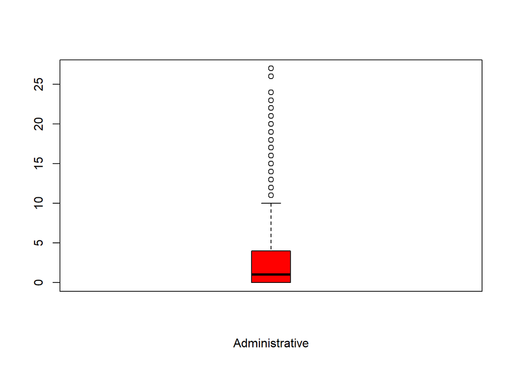

```r
boxplot(num$Administrative,col = "red",xlab ='Administrative', boxwex=0.2)
```

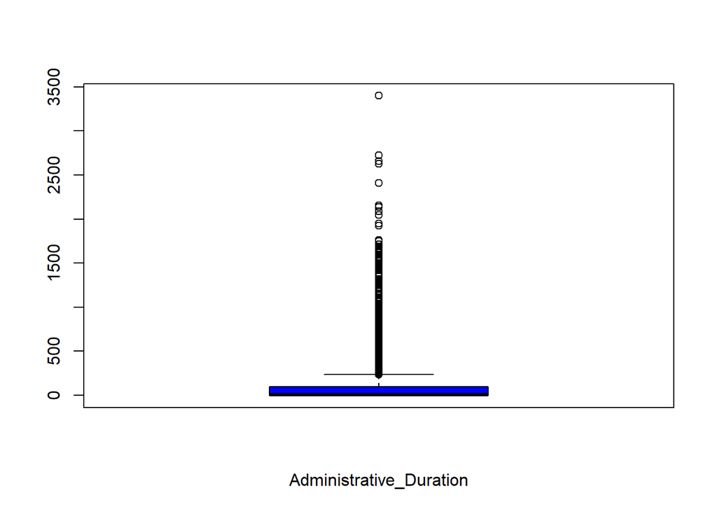

```r
boxplot(num$Administrative_Duration,col = "blue",xlab = 'Administrative_Duration')
```

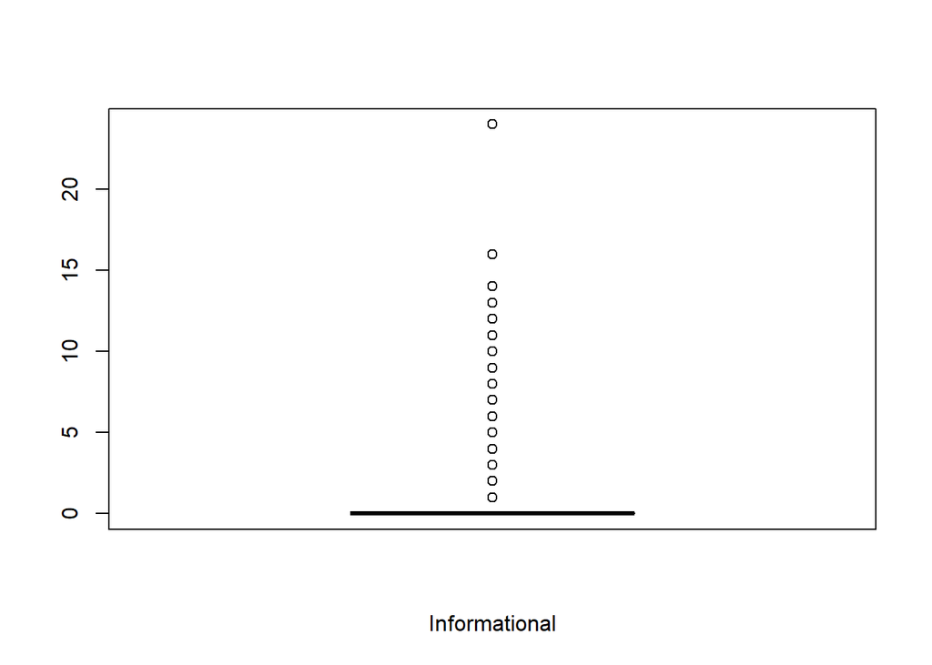

```r
boxplot(num$Informational,col = "sienna",xlab = 'Informational')
```

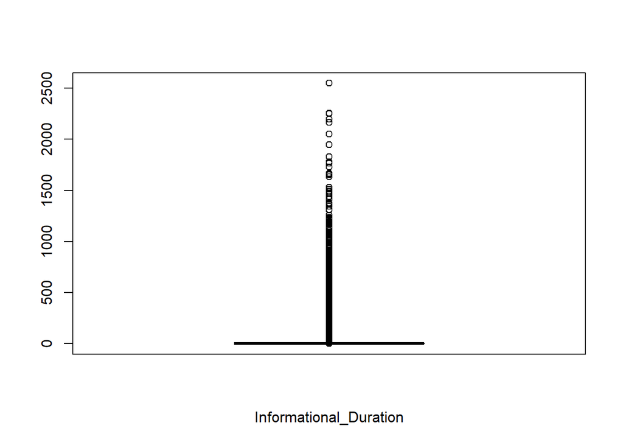

```r
boxplot(num$Informational_Duration,col = "yellow",xlab = 'Informational_Duration')
```

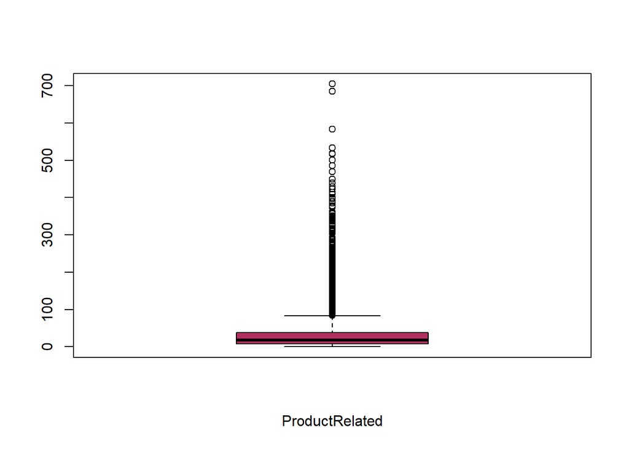

```r
boxplot(num$ProductRelated,col = "maroon",xlab = 'ProductRelated')
```

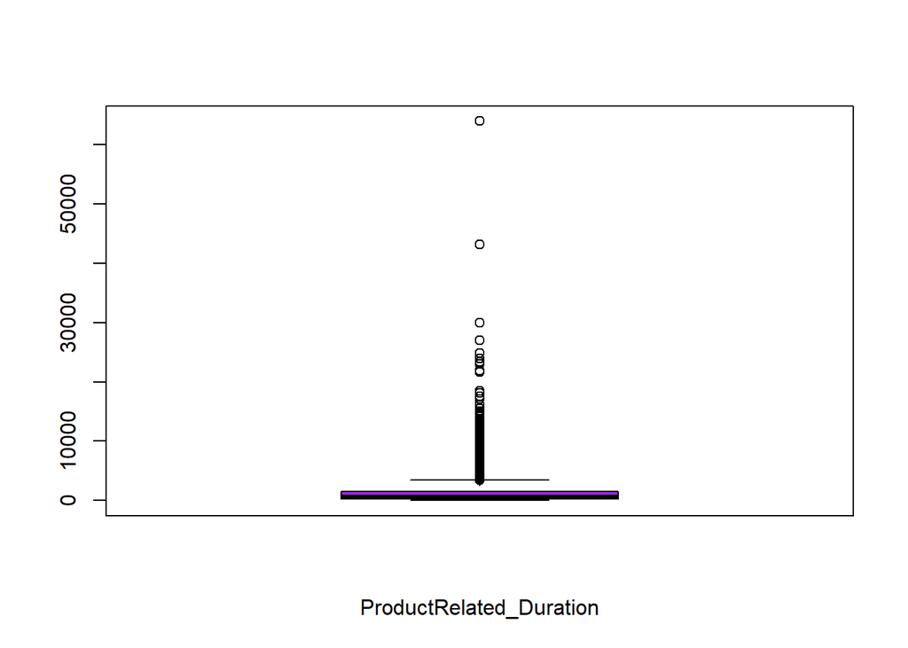

```r
boxplot(num$ProductRelated_Duration,col = "purple",xlab = 'ProductRelated_Duration')
```

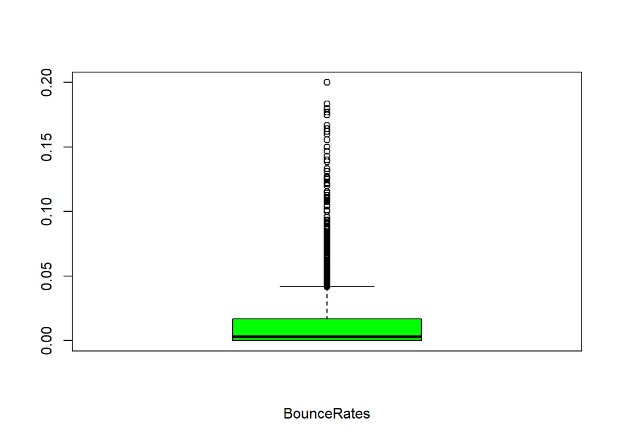

```r
boxplot(num$BounceRates,col = "green",xlab = 'BounceRates')
```

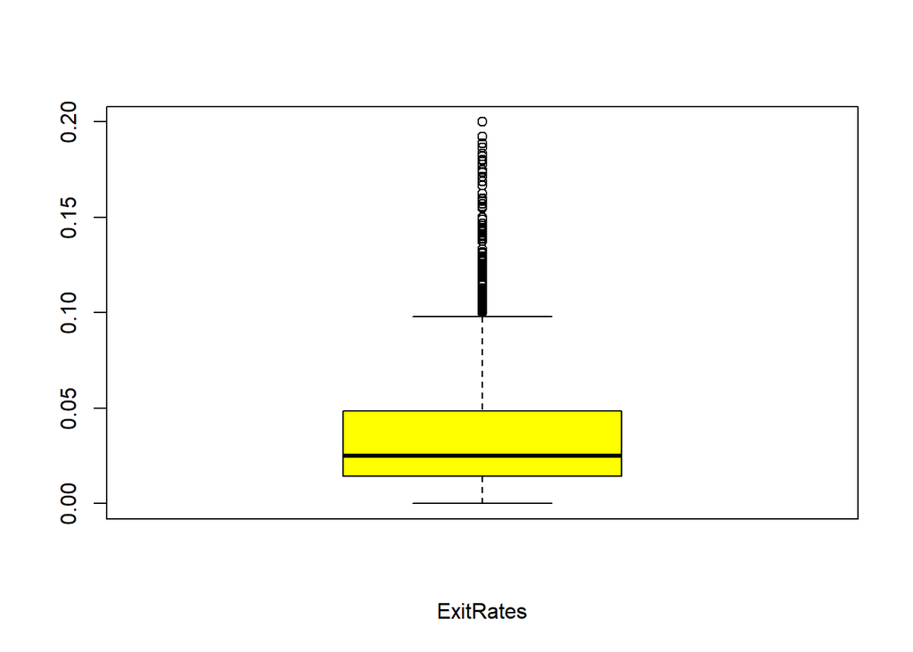

```r
boxplot(num$ExitRates,col = "yellow",xlab = 'ExitRates')
```

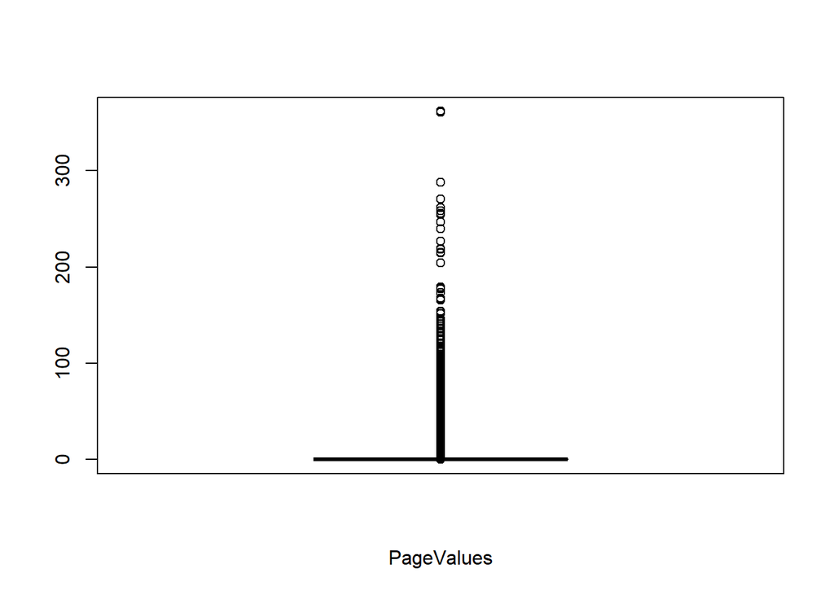

```r
boxplot(num$PageValues,col = "cyan",xlab = 'PageValues')
```

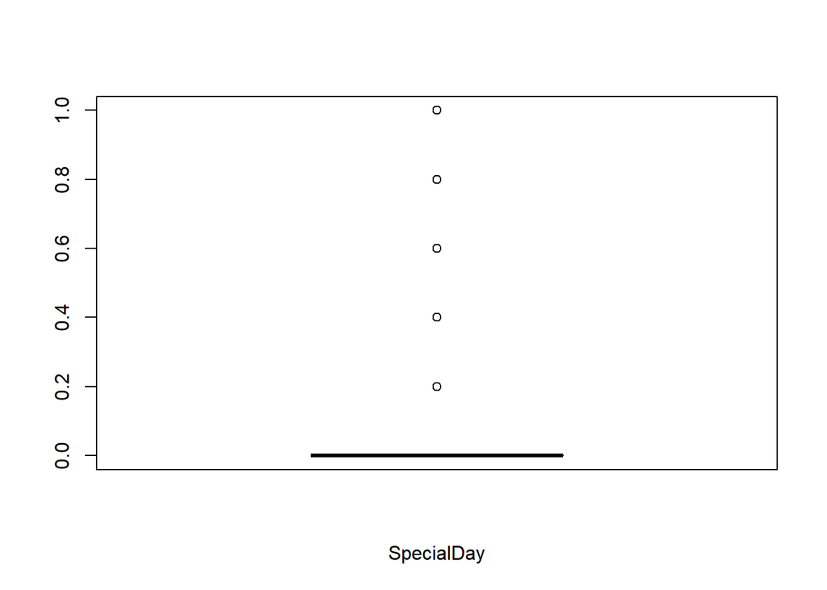

```r
boxplot(num$SpecialDay,col = "pink",xlab = 'SpecialDay')
```

# Univariate analysis

## Frequency tables

```r
table(ecommerce$VisitorType)
```

```
##
##       New_Visitor             Other Returning_Visitor
##              1693                81             10437
```

From the analysis above we can see that they had many returning visitors

```r
table(ecommerce$Month)
```

```
##
##  Aug  Dec  Feb  Jul June  Mar  May  Nov  Oct  Sep
##  433 1706  182  432  285 1864 3329 2983  549  448
```

We can also see that May was the month with the most visits

```r
table(ecommerce$TrafficType)
```

```
##
##    1    2    3    4    5    6    7    8    9   10   11   12   13   14   15
## 2390 3909 2018 1066  260  443   40  343   41  450  247    1  729   13   37
##   16   17   18   19   20
##    3    1   10   17  193
```

## Histogram

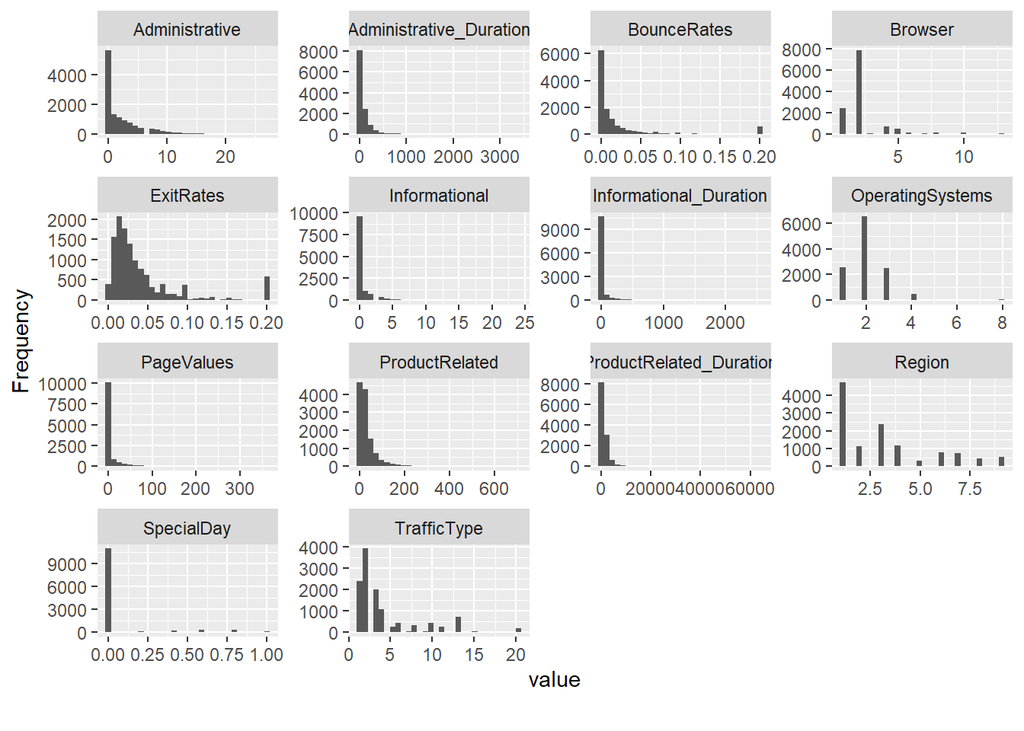

```r
plot_histogram(edf)
```

## Distribution

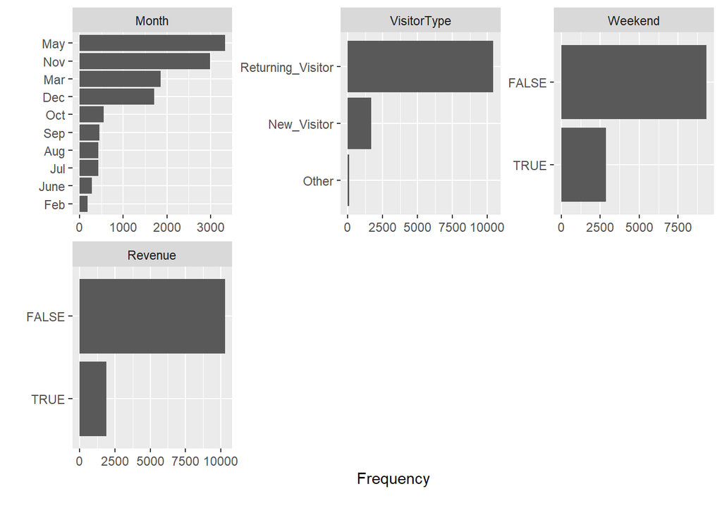

```r
plot_bar(edf)
```

# Bivariate analysis

```r
cor(edf$Administrative ,edf$Administrative_Duration)
```

```
## [1] 0.6004097
```

```r
cor(edf$Informational,edf$Informational_Duration)
```

```
## [1] 0.6186779
```

```r
cor(edf$ProductRelated,edf$ProductRelated_Duration)
```

```
## [1] 0.8603082
```

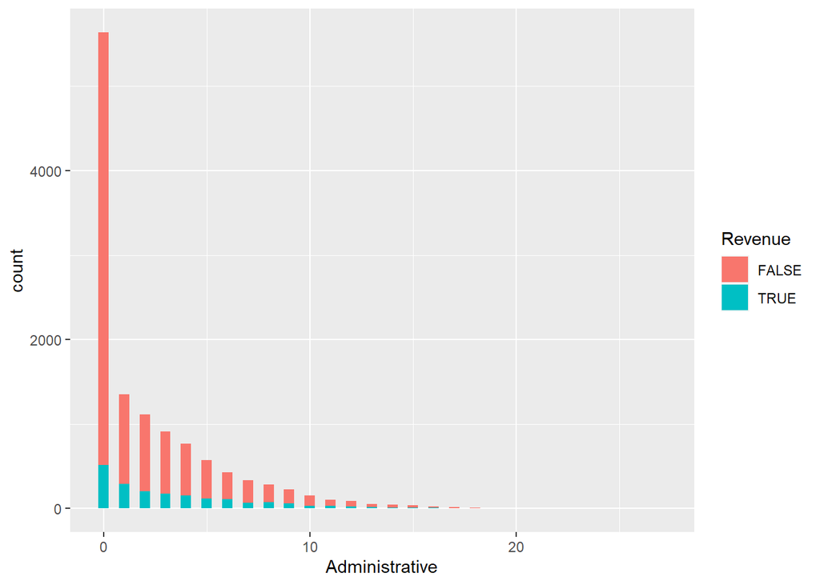

```r
library(ggplot2)

j = ggplot(data = edf, aes(x = Administrative , fill = Revenue))+
geom_bar(width = 0.5)
j
```

Most administrative counts have false revenues than true ones

# Multivariate analysis

### Correlation

```r
num <- edf[, c(1,2,3,4,5,6,7,8,9,10)]
```

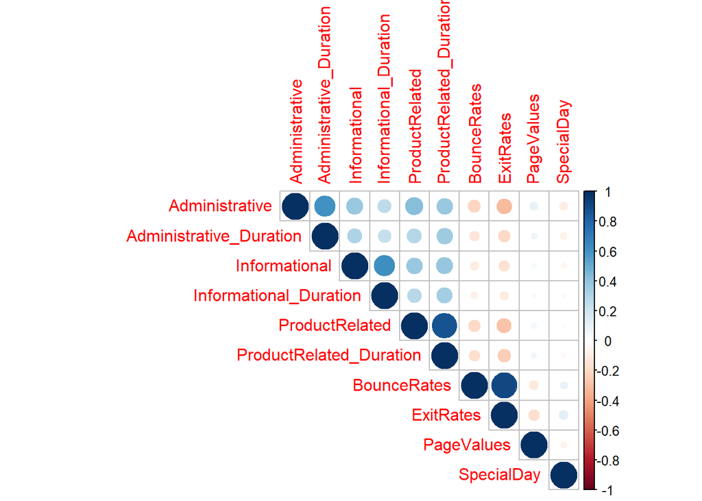

```r
data.cor = cor(num)
corrplot(data.cor, type = 'upper')
```

### Pairplot

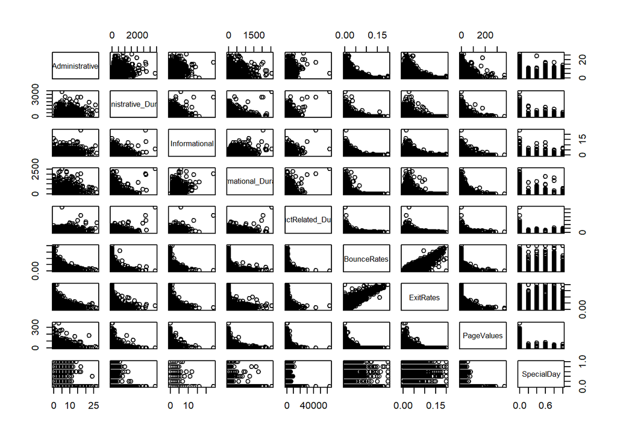

```r
pairs(edf[,c(1,2,3,4,6,7,8,9,10)])
```

### Correlation matrix

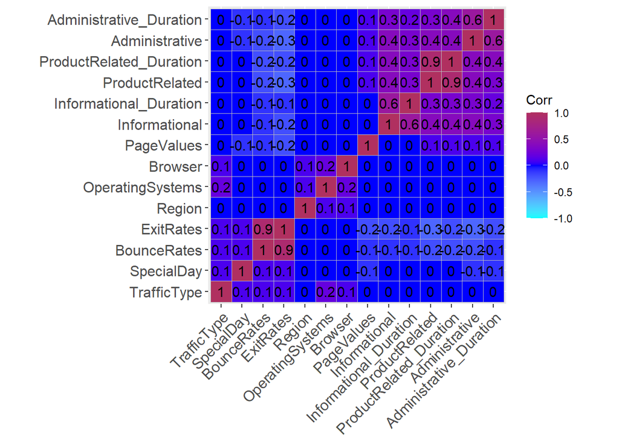

```r
options(repr.plot.width=20,repr.plot.height = 20)
corr = round(cor(select_if(edf, is.numeric)), 1)
ggcorrplot(corr, hc.order = T, ggtheme = ggplot2::theme_grey,
           colors = c("cyan", "blue", "maroon"), lab = T)
```

## Feature importance

```r
data.pca <- prcomp(edf[,c(1,2,3,4,5,6,7,8,9,10)], center = TRUE,scale. = TRUE)

summary(data.pca)
```

```
## Importance of components:
##                           PC1    PC2    PC3    PC4     PC5     PC6     PC7
## Standard deviation     1.8376 1.2984 1.0342 1.0062 0.97066 0.96313 0.65070
## Proportion of Variance 0.3377 0.1686 0.1070 0.1013 0.09422 0.09276 0.04234
## Cumulative Proportion  0.3377 0.5062 0.6132 0.7145 0.80868 0.90144 0.94378
##                            PC8     PC9   PC10
## Standard deviation     0.59361 0.35198 0.2932
## Proportion of Variance 0.03524 0.01239 0.0086
## Cumulative Proportion  0.97902 0.99140 1.0000
```

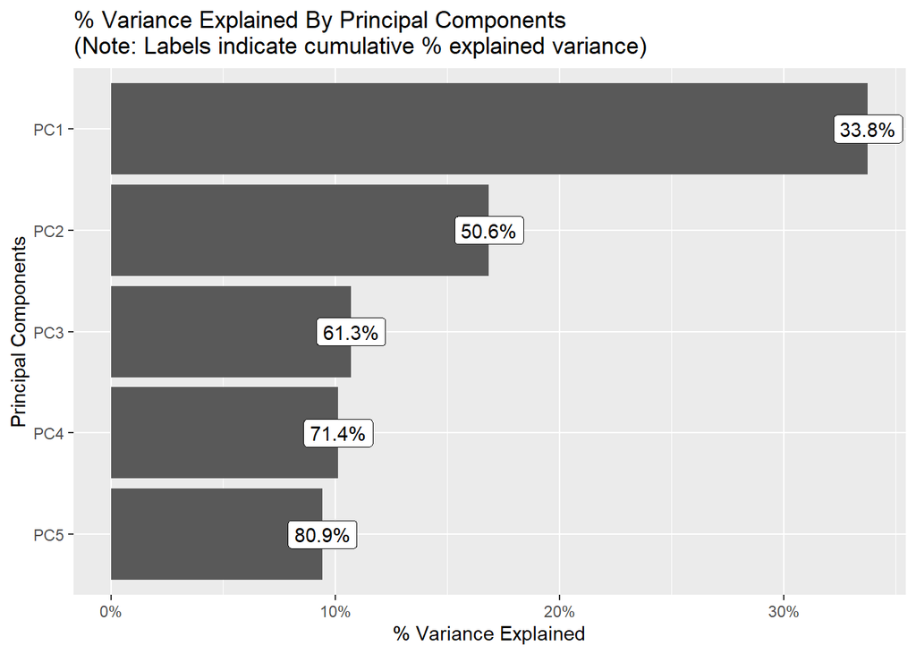

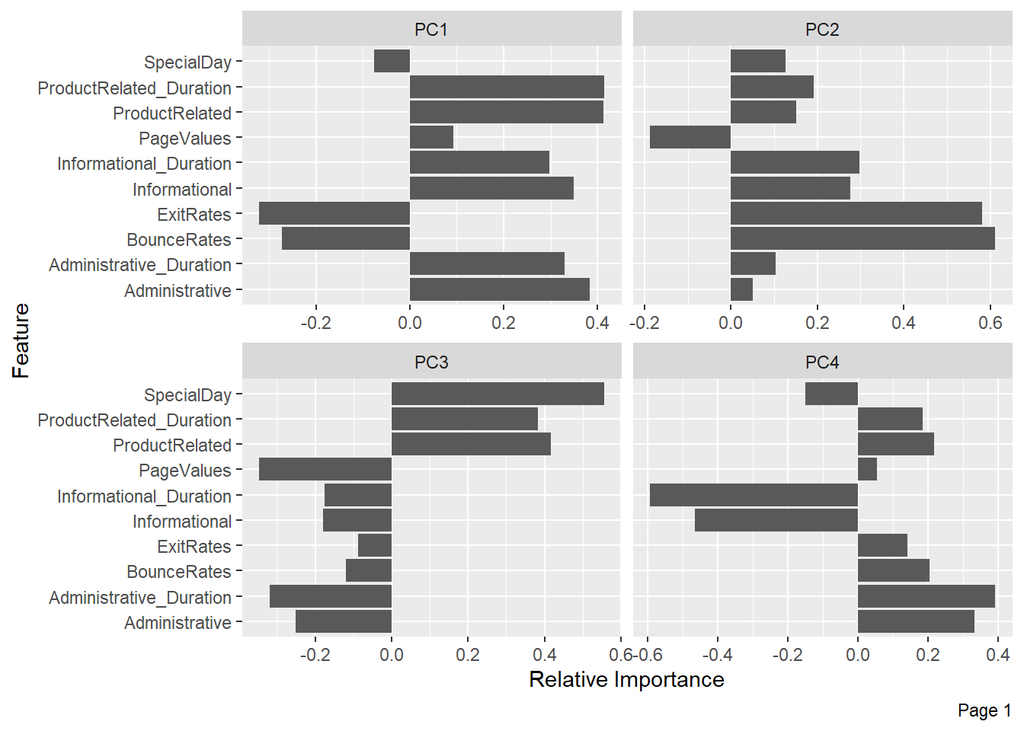

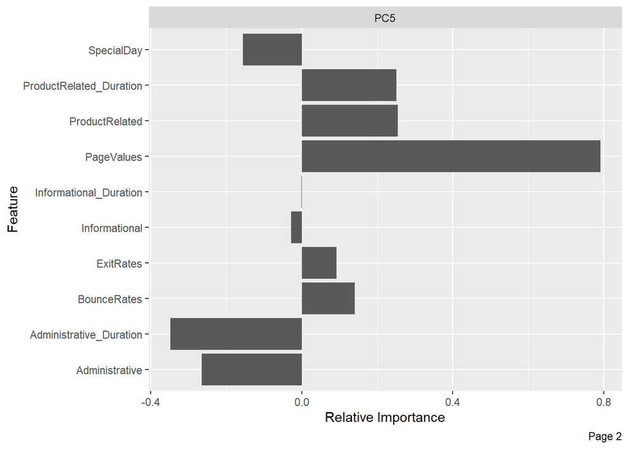

```r
plot_prcomp(num, variance_cap = 0.9, nrow = 2L, ncol = 2L)
```

# Creating new dataframe

```r
edf.new <- edf[,c(1:17)]
```

```r
edf.class <- edf["Revenue"]
```

## Normalize the data

```r
normalize <- function(x){
  return ((x-min(x)) / (max(x)-min(x)))
}
edf.new$Administrative <-normalize(edf.new$Administrative)
edf.new$Administrative_Duration <-normalize(edf.new$Administrative_Duration)
edf.new$Informational <-normalize(edf.new$Informational)
edf.new$Informational_Duration <-normalize(edf.new$Informational_Duration)
edf.new$ProductRelated <-normalize(edf.new$ProductRelated)
edf.new$ProductRelated_Duration <-normalize(edf.new$ProductRelated_Duration)
edf.new$BounceRates <-normalize(edf.new$BounceRates)
edf.new$ExitRates <-normalize(edf.new$ExitRates)
edf.new$PageValues <-normalize(edf.new$PageValues)
edf.new$SpecialDay <-normalize(edf.new$SpecialDay)
edf.new$OperatingSystems <-normalize(edf.new$OperatingSystems)
edf.new$Browser <-normalize(edf.new$Browser)
edf.new$Region<-normalize(edf.new$Region)
edf.new$TrafficType <-normalize(edf.new$TrafficType)
```

## Storing numeric data

```r
edf.clust <- edf.new[,c("Administrative","Administrative_Duration","Informational","Informational_Duration","ProductRelated","ProductRelated_Duration","BounceRates","ExitRates","PageValues","SpecialDay","OperatingSystems","Browser","Region","TrafficType")]
```

## Applying K-mean clustering

```r
results<-kmeans(edf.clust,3)
```

## Preview the no of records in each cluster

```r
results$size
```

```
## [1]  861 2627 8711
```

## Cluster centers

```r
results$centers
```

```
##   Administrative Administrative_Duration Informational
## 1    0.001935734            0.0007920694  0.0004839334
## 2    0.089512047            0.0247528081  0.0200006344
## 3    0.094184875            0.0265150825  0.0236099950
##   Informational_Duration ProductRelated ProductRelated_Duration
## 1           0.0003940119    0.004497492            0.0009901983
## 2           0.0120946087    0.044160613            0.0184999631
## 3           0.0159919661    0.049918787            0.0207774956
##   BounceRates ExitRates PageValues SpecialDay OperatingSystems   Browser
## 1  0.84835078 0.9085890 0.00000000 0.12125436        0.1703999 0.1102400
## 2  0.04442756 0.1526189 0.01892959 0.05390179        0.1718419 0.1317726
## 3  0.04591980 0.1547321 0.01733391 0.05854667        0.1562720 0.1078617
##      Region TrafficType
## 1 0.2637921   0.2269699
## 2 0.7510468   0.1687737
## 3 0.1243686   0.1532847
```

## Plot dist in clusters

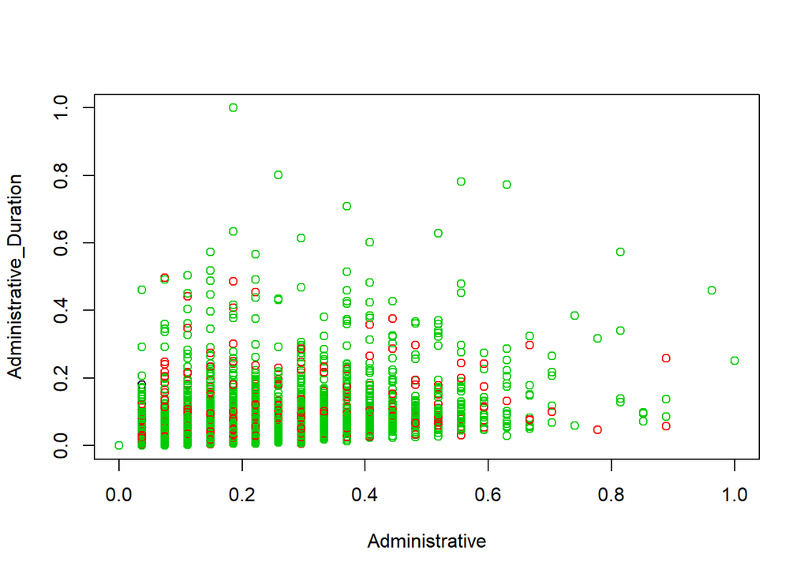

```r
plot(edf.clust[c(1,2)],col = results$cluster)
```

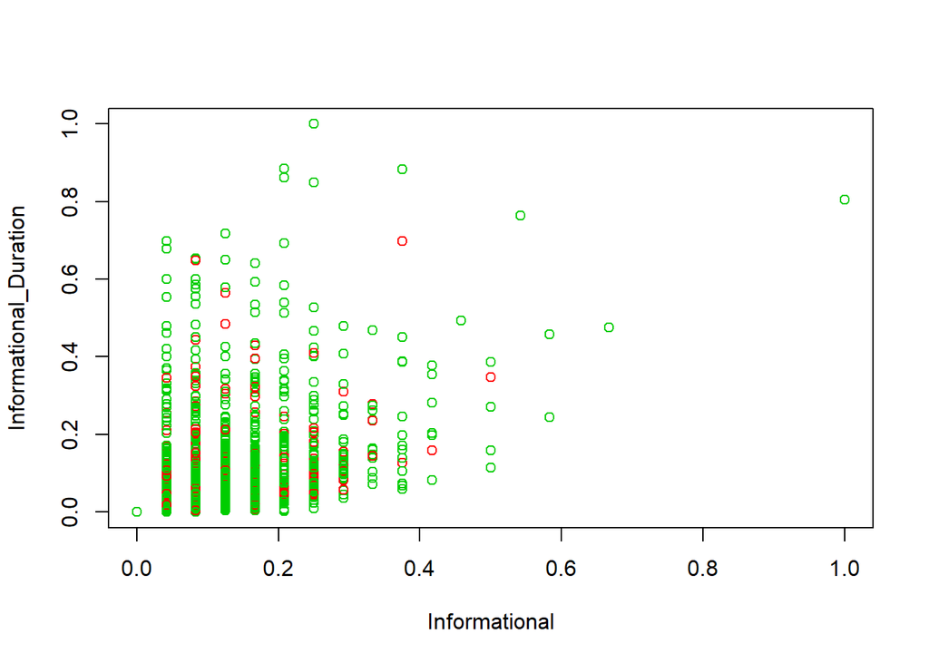

```r
plot(edf.clust[c(3,4)],col = results$cluster)
```

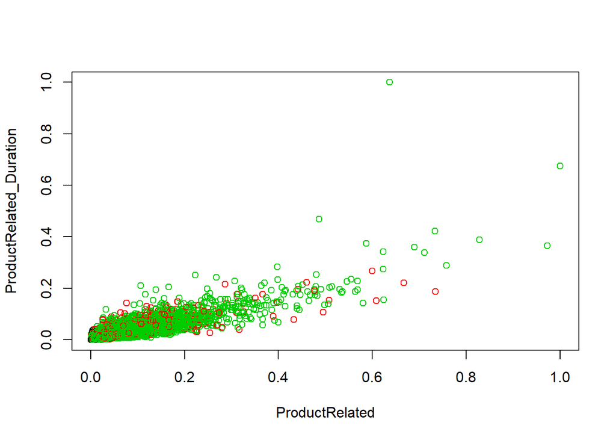

```r
plot(edf.clust[c(5,6)],col = results$cluster)
```

## convert edf.clss to numeric

```r
edf.class[] <-lapply(edf.class,as.numeric)
sapply(edf.class,class)
```

```
##   Revenue
## "numeric"
```

## Accuracy

```r
mean(edf.new==results$cluster)
```

```
## [1] 0.006774904
```

# Hierachical clustering

## Descriptive stats of edf.clust

```r
summary(round(edf.clust,1))
```

```
##  Administrative    Administrative_Duration Informational
##  Min.   :0.00000   Min.   :0.00000         Min.   :0.00000
##  1st Qu.:0.00000   1st Qu.:0.00000         1st Qu.:0.00000
##  Median :0.00000   Median :0.00000         Median :0.00000
##  Mean   :0.08175   Mean   :0.01911         Mean   :0.01809
##  3rd Qu.:0.10000   3rd Qu.:0.00000         3rd Qu.:0.00000
##  Max.   :1.00000   Max.   :1.00000         Max.   :1.00000
##  Informational_Duration ProductRelated    ProductRelated_Duration
##  Min.   :0.0000         Min.   :0.00000   Min.   :0.000000
##  1st Qu.:0.0000         1st Qu.:0.00000   1st Qu.:0.000000
##  Median :0.0000         Median :0.00000   Median :0.000000
##  Mean   :0.0121         Mean   :0.03584   Mean   :0.009771
##  3rd Qu.:0.0000         3rd Qu.:0.10000   3rd Qu.:0.000000
##  Max.   :1.0000         Max.   :1.00000   Max.   :1.000000
##   BounceRates        ExitRates        PageValues        SpecialDay
##  Min.   :0.00000   Min.   :0.0000   Min.   :0.00000   Min.   :0.00000
##  1st Qu.:0.00000   1st Qu.:0.1000   1st Qu.:0.00000   1st Qu.:0.00000
##  Median :0.00000   Median :0.1000   Median :0.00000   Median :0.00000
##  Mean   :0.09851   Mean   :0.2049   Mean   :0.01491   Mean   :0.06197
##  3rd Qu.:0.10000   3rd Qu.:0.2000   3rd Qu.:0.00000   3rd Qu.:0.00000
##  Max.   :1.00000   Max.   :1.0000   Max.   :1.00000   Max.   :1.00000
##  OperatingSystems    Browser           Region        TrafficType
##  Min.   :0.0000   Min.   :0.0000   Min.   :0.0000   Min.   :0.0000
##  1st Qu.:0.1000   1st Qu.:0.1000   1st Qu.:0.0000   1st Qu.:0.1000
##  Median :0.1000   Median :0.1000   Median :0.2000   Median :0.1000
##  Mean   :0.1395   Mean   :0.1206   Mean   :0.2618   Mean   :0.1801
##  3rd Qu.:0.3000   3rd Qu.:0.1000   3rd Qu.:0.4000   3rd Qu.:0.2000
##  Max.   :1.0000   Max.   :1.0000   Max.   :1.0000   Max.   :1.0000
```

## scaling our data

Transforms our data to have a mean of 0 and std of 1

```r
edf.clust <- scale(edf.clust)
head(edf.clust)
```

```
##      Administrative Administrative_Duration Informational
## [1,]     -0.7025315              -0.4601081    -0.3988128
## [2,]     -0.7025315              -0.4601081    -0.3988128
## [3,]     -0.7025315              -0.4657410    -0.3988128
## [4,]     -0.7025315              -0.4601081    -0.3988128
## [5,]     -0.7025315              -0.4601081    -0.3988128
## [6,]     -0.7025315              -0.4601081    -0.3988128
##      Informational_Duration ProductRelated ProductRelated_Duration
## [1,]             -0.2462725     -0.6963635              -0.6289343
## [2,]             -0.2462725     -0.6739424              -0.5955997
## [3,]             -0.2533417     -0.6963635              -0.6294551
## [4,]             -0.2462725     -0.6739424              -0.6275453
## [5,]             -0.2462725     -0.4945739              -0.3020990
## [6,]             -0.2462725     -0.2927843              -0.5486101
##       BounceRates  ExitRates PageValues SpecialDay OperatingSystems
## [1,]  3.954699721  3.4273070 -0.3190356 -0.3103105       -1.2396607
## [2,] -0.450343788  1.2650121 -0.3190356 -0.3103105       -0.1371074
## [3,]  3.954699721  3.4273070 -0.3190356 -0.3103105        2.0679992
## [4,]  0.650917089  2.1299300 -0.3190356 -0.3103105        0.9654459
## [5,] -0.009839437  0.1838646 -0.3190356 -0.3103105        0.9654459
## [6,] -0.102577188 -0.3661929 -0.3190356 -0.3103105       -0.1371074
##         Browser     Region TrafficType
## [1,] -0.7939682 -0.8962939 -0.76562243
## [2,] -0.2093703 -0.8962939 -0.51660683
## [3,] -0.7939682  2.4336556 -0.26759123
## [4,] -0.2093703 -0.4800502 -0.01857564
## [5,]  0.3752276 -0.8962939 -0.01857564
## [6,] -0.2093703 -0.8962939 -0.26759123
```

# defining the distance that we will use

```r
d <-dist(edf.clust,method = "euclidian")
```

## clustering using hclust() fx

```r
edf.hc <- hclust (d,method = "ward.D2")
```

## Dendogram plot

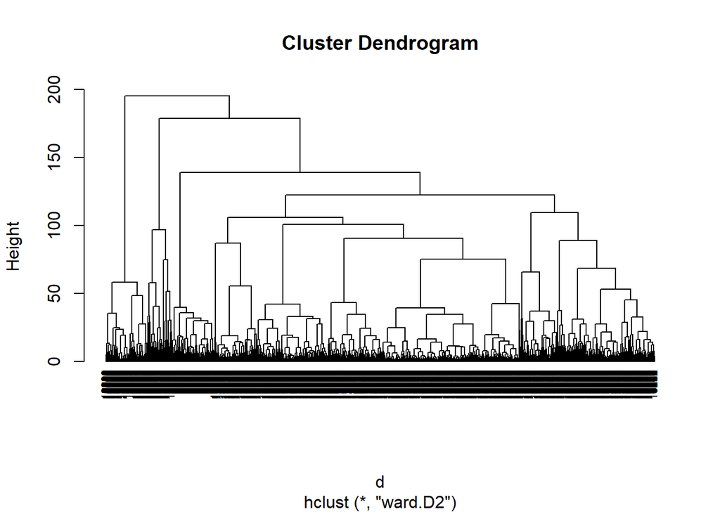

```r
plot(edf.hc,cex = 0.6,hang = -1)
```

## cut the tree into three

```r
sub_group = cutree(edf.hc,k=3)
table(sub_group)
```

```
## sub_group
##     1     2     3
##   932 10743   524
```